# Introduction to Item Analysis Using `itemanalysis` Package

Cengiz Zopluoglu

University of Oregon

09/7/2024

[Updated: Sat, Sep 07, 2024 - 08:48:35 ]

# 1. Overview

The itemanalysis package in R is designed to facilitate classical item analysis for both multiple-choice (dichotomous) and polytomous (rating scale) test items. Classical Test Theory (CTT) provides essential item statistics such as item difficulty, discrimination, and distractor analysis, which help in evaluating the quality of test items.

This tutorial will guide you through running item analysis for both dichotomous and polytomous datasets using the itemanalysis package.

(*Note that there are much better tools available for free to run classical item analysis. This package was originally developed in 2013 to supplement the content I was teaching in a measurement course at the University of Miami. Therefore, it is customized and aligned with the content I taught.*)

# 2. Installation and Setup

Before starting, you need to install and load the package. Since the package may not be available on CRAN, you can download it from the source or GitHub (if applicable) or use the pre-installed package.

```r
# Install the package (if not already installed)
# install.packages("itemanalysis")

# Load the package
require(itemanalysis)
```

# 3. Running Item Analysis on Dichotomously Scored Items

We will use a multiple-choice dataset where each item has one correct answer, and the responses are nominal (e.g., A, B, C, D). The dataset `dichotomous` is included in the package. It contains 6,000 rows (examinees) and 56 columns (items), with each cell representing the nominal response to a particular item.

```r
# Load the dataset
data(dichotomous)
head(dichotomous)
```

```
  item1 item2 item3 item4 item5 item6 item7 item8 item9 item10 item11 item12
1     A     A     D     D     C     B     C     D     D      D      C      A
2     A     B     C     C     C     B     A     D     A      D      C      A
3     A     C     D     B     D     D     D     D     A      D      C      A
4     A     B     D     B     D     D     C     D     A      C      C      B
5     A     D     C     B     C     B     C     D     B      D      C      A
6     D     C     B     C     A     B     C     D     A      D      A      B
  item13 item14 item15 item16 item17 item18 item19 item20 item21 item22 item23
1      D      C      A      B      D      B      A      B      B      A      D
2      D      C      A      B      A      D      A      C      B      A      C
3      D      D      A      B      A      A      A      C      B      C      C
4      D      D      A      A      D      B      D      C      D      A      C
5      D      C      A      A      A      B      A      C      B      C      A
6      D      D      B      C      B   <NA>      D      B      B      A      C
  item24 item25 item26 item27 item28 item29 item30 item31 item32 item33 item34
```

[output cut: 20 more lines]

The answer key is a vector that specifies the correct answer for each item.

```r
# Define the correct answers for each item

key <- c("A","D","C","B","C","B","C","D","A","D","C","A","D","C","A",
         "B","D","B","A","C","A","A","C","B","C","B","D","A","A","A",
         "C","B","B","A","B","D","D","A","D","C","D","A","B","B","C",
         "D","B","C","C","B","D","A","C","B","A","D")
```

Use the `itemanalysis1` function to run the analysis. You can customize parameters such as the number of score groups (`ngroup`) and whether to apply correction for point-biserial correlation.

```r
item.analysis <- itemanalysis1(
  data       = dichotomous,             # a data frame object with N rows and m columns
  key        = key,                     # a vector of correct answers with length m
  options    = c("A", "B", "C", "D"),   # a vector of available response options
  ngroup     = 10,                      # number of score groups to be use for plotting the item trace lines
  correction = F,                       # if it is TRUE, then an adjustment is made for point-biserial correlation
                                        # recommended for tests with small number of items
  span.par   = 0.3,                     #   a smoothing parameter to pass to ggplots when creating empirical item trace lines,
  verbose    = T                        # if it is TRUE, text output is printed in console
)
```

```
itemanalysis: An R package for Classical Test Theory Item Analysis

Cengiz Zopluoglu

University of Oregon
College of Education

cen.zop@gmail.com

Please report any programming bug or problem you experience to improve the code.
Processing Date:  Sat Sep  7 08:48:41 2024

                                   ITEM STATISTICS

       Item Difficulty Item Threshold Point-Biserial Biserial
item1            0.709         -0.551          0.349    0.462
item2            0.530         -0.075          0.304    0.381
item3            0.812         -0.885          0.440    0.638
item4            0.574         -0.185          0.281    0.354
item5            0.653         -0.393          0.334    0.431
item6            0.733         -0.621          0.384    0.517
item7            0.460          0.101          0.361    0.453
item8            0.856         -1.060          0.442    0.684
item9            0.544         -0.110          0.361    0.453
item10           0.808         -0.872          0.490    0.707
item11           0.827         -0.941          0.477    0.705
item12           0.553         -0.132          0.372    0.468
item13           0.772         -0.745          0.505    0.701
item14           0.473          0.067          0.345    0.433
item15           0.640         -0.360          0.480    0.616
item16           0.447          0.133          0.343    0.431
item17           0.434          0.166          0.379    0.477
item18           0.488          0.030          0.341    0.427
item19           0.668         -0.434          0.559    0.725
item20           0.502         -0.005          0.377    0.473
item21           0.572         -0.181          0.445    0.561
item22           0.437          0.159          0.420    0.529
item23           0.370          0.331          0.353    0.451
item24           0.569         -0.175          0.543    0.684
item25           0.503         -0.009          0.461    0.578
```

[output cut: 202 more lines]

```
item42  0.477 -0.400 -0.339  0.070
item43 -0.278  0.536 -0.213 -0.382
item44 -0.076  0.478 -0.233 -0.228
item45 -0.266 -0.348  0.626 -0.260
item46 -0.372 -0.439 -0.208  0.676
item47 -0.231  0.534 -0.347 -0.108
item48 -0.380 -0.312  0.561 -0.105
item49 -0.263 -0.168  0.476 -0.134
item50 -0.427  0.744 -0.415 -0.391
item51 -0.464 -0.459 -0.405  0.785
item52  0.605 -0.153 -0.410 -0.350
item53 -0.196 -0.307  0.567 -0.202
item54 -0.092  0.360 -0.064 -0.161
item55  0.500 -0.217 -0.217 -0.132
item56 -0.406 -0.405 -0.361  0.716
```

The function prints the output in the console by default. If you want to turn this feature off, you can add `verbose=F` argument. In either case, you can always access to the outputs from the function as separate data objects using the following code.

```r
item.analysis$item.stat  # returns a matrix of basic item statistics

item.analysis$dist.sel   # returns a matrix of distractor selection proportion statistics

item.analysis$dist.disc  # returns a matrix of point-biserial statistics for distractors
```

The function also creates and saves the item trace lines for each item in the `plot` output, a list object, that can be accessed as follows. A default value of 0.3 is used for the `span.par` argument in the function and this is being passed to the `ggplot` pacage for smoothing the lines. If you’d like to change it, you can add `span.par=` argument with a custom value to the function.

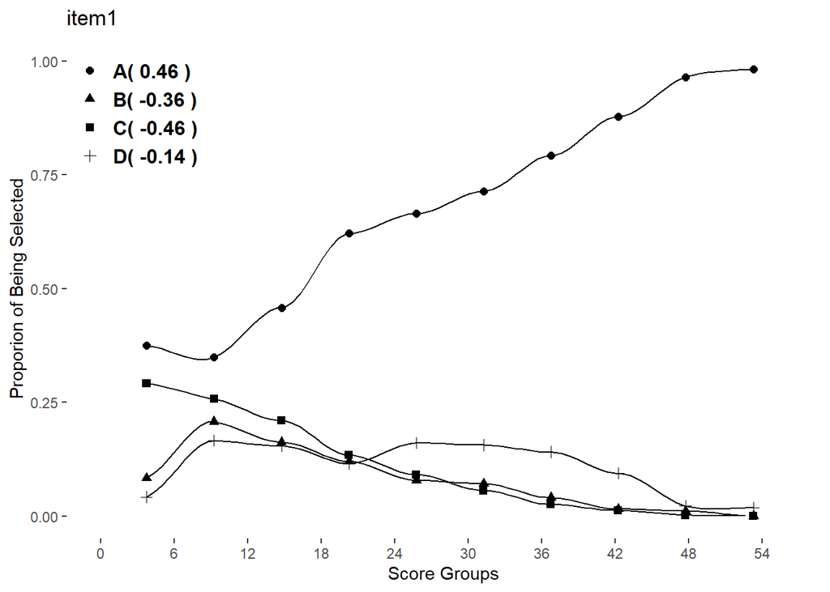

```r
# Plot item trace lines for the first item
item.analysis$plots[[1]]
```

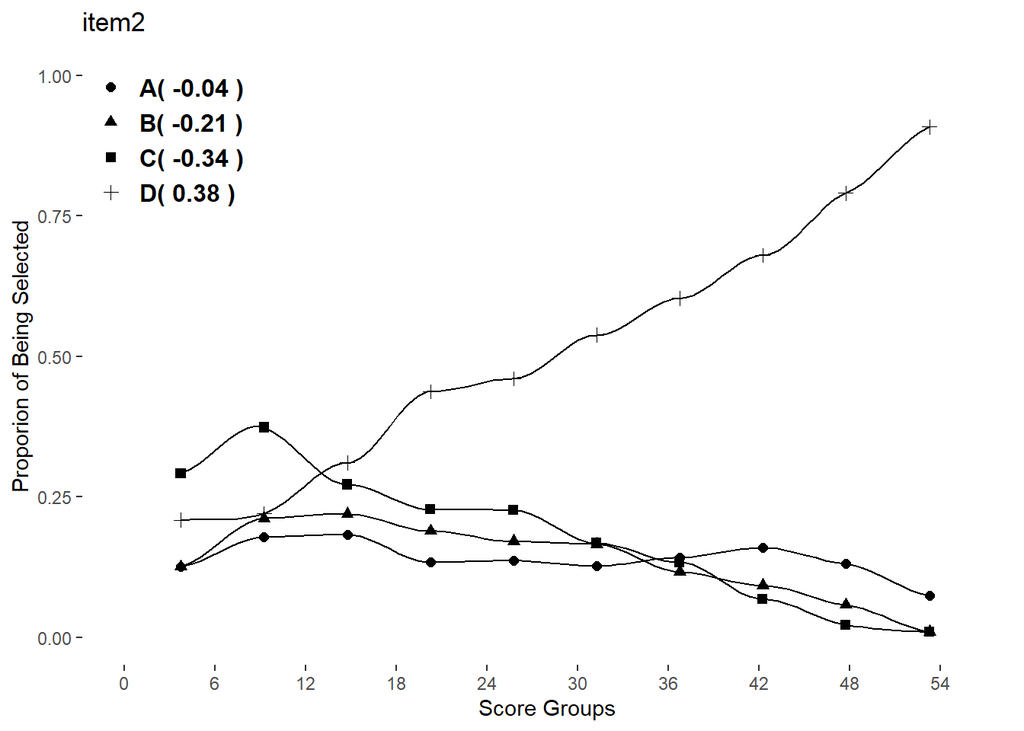

```r
# Plot item trace lines for the second item
item.analysis$plots[[2]]
```

# 4. Running Item Analysis on Polytomously Scored Items

Next, we’ll analyze a dataset where the responses are polytomous, meaning that they use multiple response categories such as those found in rating scales (e.g., Likert scales). The example below uses the TIMSS 2011 USA dataset (`timss2011_usa`), which includes items measuring attitudes towards mathematics.

The items are as follows:

- Q14A, I enjoy learning mathematics
- Q14B, I wish have not to study Math
- Q14C, Mathematics is boring
- Q14D, I learn interesting things in mathematics class
- Q14E, I like mathematics
- Q14F, I think it’s important to do well in mathematics

Before analysis, note that Q14B and Q14C must be reverse coded to align with the other items. These two items reflect negative attitudes towards mathematics, whereas the other four reflect positive attitudes.

This dataset, which is included in the package, contains responses to six items. Each item is scored on a scale from 0 to 3, where 0 indicates “strongly disagree” and 3 indicates “strongly agree.”

```r
# Load the dataset
data(timss2011_usa)
head(timss2011_usa)
```

```
  Q14A Q14B Q14C Q14D Q14E Q14F
1    0    3    3    1    0    3
2    2    2    3    3    2    3
3    2    1    2    2    1    3
4    3    1    1    2    3    3
5    3    0    2    3    3    3
6    0    3    3    1    0    3
```

```r
#  Two items needs to be reverse coded for alignment

timss2011_usa$Q14B <- recode(var = timss2011_usa$Q14B,
                             recodes = "c(0)=3;c(1)=2;c(2)=1;c(3)=0")

timss2011_usa$Q14C <- recode(var = timss2011_usa$Q14C,
                             recodes = "c(0)=3;c(1)=2;c(2)=1;c(3)=0")
```

Use the `itemanalysis2` function to run the analysis for polytomous items. You can specify response categories using the options argument.

```r
# Run item analysis for polytomous items
item.analysis.poly <- itemanalysis2(
  data       = timss2011_usa, # a data frame object with N rows and m columns
  options    = c(0, 1, 2, 3), # a vector of numerical code of the response categories available in the data
  ngroup     = 10,            # number of score groups to be use for plotting the item trace lines
  correction = T,             # if it is TRUE, then an adjustment is made for point-biserial correlation
                              # recommended for scale with small number items
  span.par   = .3,            # a smoothing parameter to pass to ggplots when creating empirical item trace lines
  verbose    = T              # if it is TRUE, text output is printed in console.
)
```

```
itemanalysis: An R package for Classical Test Theory Item Analysis

Cengiz Zopluoglu

University of Oregon
College of Education

cen.zop@gmail.com

Please report any programming bug or problem you experience to improve the code.
Processing Date:  Sat Sep  7 08:48:46 2024
                                   ITEM STATISTICS

       Mean Score Item Difficulty Point-Biserial Polyserial
Item 1      1.763           0.588          0.811      0.877
Item 2      1.599           0.533          0.654      0.704
Item 3      1.379           0.460          0.694      0.745
Item 4      1.864           0.621          0.663      0.717
Item 5      1.702           0.567          0.817      0.884
Item 6      2.709           0.903          0.346      0.480

    * Item difficulty is the ratio of mean score to possible maximum score
      and assumes the minimum score is 0


           RESPONSE CATEGORY SELECTION PROPORTIONS

           0     1     2     3
Item 1 0.161 0.189 0.375 0.274
Item 2 0.200 0.263 0.275 0.262
Item 3 0.240 0.330 0.242 0.188
Item 4 0.114 0.206 0.384 0.297
Item 5 0.189 0.191 0.351 0.270
Item 6 0.021 0.026 0.176 0.777



      RESPONSE CATEGORY Point-Biserial Correlation

            0      1      2     3
Item 1 -0.602 -0.281  0.109 0.625
Item 2 -0.545 -0.136  0.152 0.478
Item 3 -0.627 -0.023  0.232 0.458
Item 4 -0.469 -0.278  0.059 0.509
Item 5 -0.628 -0.247  0.132 0.629
Item 6 -0.195 -0.135 -0.230 0.329


            RESPONSE CATEGORY Biserial Correlation

            0      1      2     3
Item 1 -0.905 -0.407  0.139 0.837
Item 2 -0.779 -0.183  0.203 0.645
Item 3 -0.862 -0.030  0.318 0.664
Item 4 -0.773 -0.395  0.075 0.672
Item 5 -0.909 -0.356  0.171 0.845
Item 6 -0.552 -0.357 -0.338 0.459
```

The function similarly prints the output in the console by default. If you want to turn this feature off, you can add verbose=F argument. In either case, you can always access to the outputs from the function as separate data objects using the following code.

```r
item.analysis.poly$item.stat  # returns a matrix of basic item statistics

item.analysis.poly$dist.sel   # returns a matrix of distractor selection proportion statistics

item.analysis.poly$dist.disc  # returns a matrix of point-biserial statistics for distractors
```

The function similarly creates and saves the item trace lines for each item that can be accessed as follows. A default value of 0.3 is used for the span.par argument in the function and this is being passed to the ggplot pacage for smoothing the lines. If you’d like to change it, you can add span.par= argument with a custom value to the function.

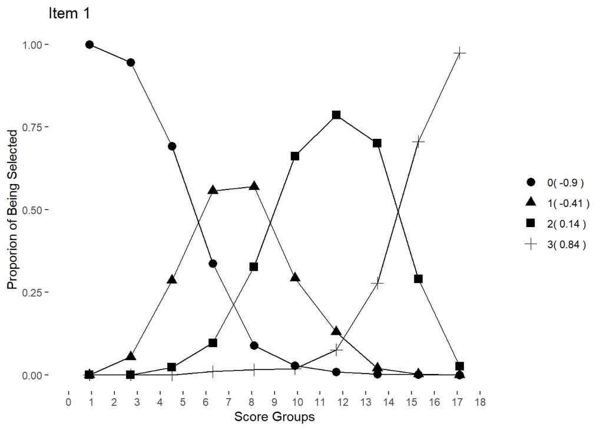

```r
# Plot item trace lines for the first item
item.analysis.poly$plots[[1]]
```